## Practical Machine Learning - Prediction Assignment

### Intro

This is a short article which briefly explores models which could be used for outcome prediction of the HAR (Human Activity Recognition) data set (http://groupware.les.inf.puc-rio.br/har). The goal is to predict the class of the activity based on the input data collected from the accelerometers attached to the human subjects.

### Data sets

Two data sets have been provided for the analysis:

1. Training data: https://d396qusza40orc.cloudfront.net/predmachlearn/pml-training.csv
2. Testing data: https://d396qusza40orc.cloudfront.net/predmachlearn/pml-testing.csv

After the first load and initial examination it was pretty clear that the training data set contain many unspecified values, e.g. NA, empty strings or #DIV/0! which may negatively influence build of the final model. In order to clean up the data sets, first step was to convert values NA, #DIV/0! and empty strings into explicit NA values.

After the clean up the number of the predictors has been reduced from 160 to only 53.

```r
library(caret)
library(rattle)
library(partykit)
library(rpart)
library(randomForest)

pmltrain <- read.csv("pml-training.csv", header=TRUE, na.strings = c("", " ","NA", "#DIV/0!"))
pmltest <- read.csv("pml-testing.csv", header=TRUE, na.strings = c("", " ","NA", "#DIV/0!"))

# cleaning data sets from NA columns
pmltrain1 <- pmltrain[, !apply(pmltrain, 2, function(x) any(is.na(x)))]
pmltest1 <- pmltest[, !apply(pmltest, 2, function(x) any(is.na(x)))]

# removing identifiers, not needed for analysis
pmltrain1 <- pmltrain1[,c(-1:-7)]
pmltest1 <- pmltest1[,c(-1:-7)]
```

### Models and training

The selection of the cases for the training has been done using the *createDataPartition* function from the *caret* library. 75% of the cases has been selected for the training data set and 25% for the testing purposes. The predicted outcome - class of the activity - is stored in the *classe* variable and the has been used as the vector of the outcomes for splitting the set into the partitions.

```r
inTrain <- createDataPartition(y = pmltrain1$classe,
                               p = 0.75,
                               list = F)
training <- pmltrain1[inTrain,]
testing <- pmltrain1[-inTrain,]
```

Three types of models have been used to find the best way to predict:

1. Recursive Partitioning and Regression Tree - applied via the *caret* package and *rpart* parameter in the *train* function. This model has been used three times with different parameters to find the most optimal configuration:
- data is preprocessed with centering, scaling and principal components analysis
- data is only centered and scaled
- data is not preprocessed

In each case the repeated K-fold cross-validation method has been applied with the setting of 3 repetitions and K = 10 (default value).

2. Classification and Regression with Random Forest - applied as the *randomForest* function from the *randomForest* library. The numbers of trees to grow has been set to 500. No cross-validation has been used with this model as “in random forests, there is no need for cross-validation or a separate test set to get an unbiased estimate of the test set error. It is estimated internally, during the run (…)” (source: https://www.stat.berkeley.edu/~breiman/RandomForests/cc_home.htm).
3. k-Nearest Neighbour Classification - applied via the *caret* package and *knn* parameter in the *train* function. The preprocessing has been done with centering, scaling and PCA. The repeated K-fold cross-validation method has been applied with the setting of 3 repetitions and K = 10.

```r
set.seed(34234)
modFit1 <- train(classe ~ ., data = training,
                method = "rpart",
                preProcess = c("center", "scale", "pca"),
                trControl = trainControl(method = "repeatedcv", repeats = 3))

modFit2 <- train(classe ~ ., data = training,
                 method = "rpart",
                 preProcess = c("center", "scale"),
                 trControl = trainControl(method = "repeatedcv", repeats = 3))

modFit3 <- train(classe ~ ., data = training,
                 method = "rpart",
                 trControl = trainControl(method = "repeatedcv", repeats = 3))

modFit4 <- randomForest(classe ~ ., data = training, ntree = 500)

modFit5 <- train(classe ~ ., data = training,
                method = "knn",
                preProcess = c("center", "scale", "pca"),
                trControl = trainControl(method = "repeatedcv", repeats = 3))
```

### Models performance and conclusions

#### Recursive Partitioning and Regression Tree

```r
predictions1 <- predict(modFit1, newdata = testing)
predictions2 <- predict(modFit2, newdata = testing)
predictions3 <- predict(modFit3, newdata = testing)
predictions4 <- predict(modFit4, newdata = testing)
predictions5 <- predict(modFit5, newdata = testing)
```

```r
confusionMatrix(predictions1, testing$classe)
```

```
## Confusion Matrix and Statistics
##
##           Reference
## Prediction    A    B    C    D    E
##          A 1283  651  808  431  485
##          B    0    0    0    0    0
##          C    0    0    0    0    0
##          D   96  171   24  317  137
##          E   16  127   23   56  279
##
## Overall Statistics
##
##                Accuracy : 0.3832
##                  95% CI : (0.3695, 0.3969)
##     No Information Rate : 0.2845
##     P-Value [Acc > NIR] : < 2.2e-16
##
##                   Kappa : 0.1711
##  Mcnemar's Test P-Value : NA
##
## Statistics by Class:
##
##                      Class: A Class: B Class: C Class: D Class: E
## Sensitivity            0.9197   0.0000   0.0000  0.39428  0.30966
## Specificity            0.3232   1.0000   1.0000  0.89561  0.94454
## Pos Pred Value         0.3507      NaN      NaN  0.42550  0.55689
## Neg Pred Value         0.9101   0.8065   0.8257  0.88290  0.85873
## Prevalence             0.2845   0.1935   0.1743  0.16395  0.18373
## Detection Rate         0.2616   0.0000   0.0000  0.06464  0.05689
## Detection Prevalence   0.7459   0.0000   0.0000  0.15192  0.10216
## Balanced Accuracy      0.6214   0.5000   0.5000  0.64494  0.62710
```

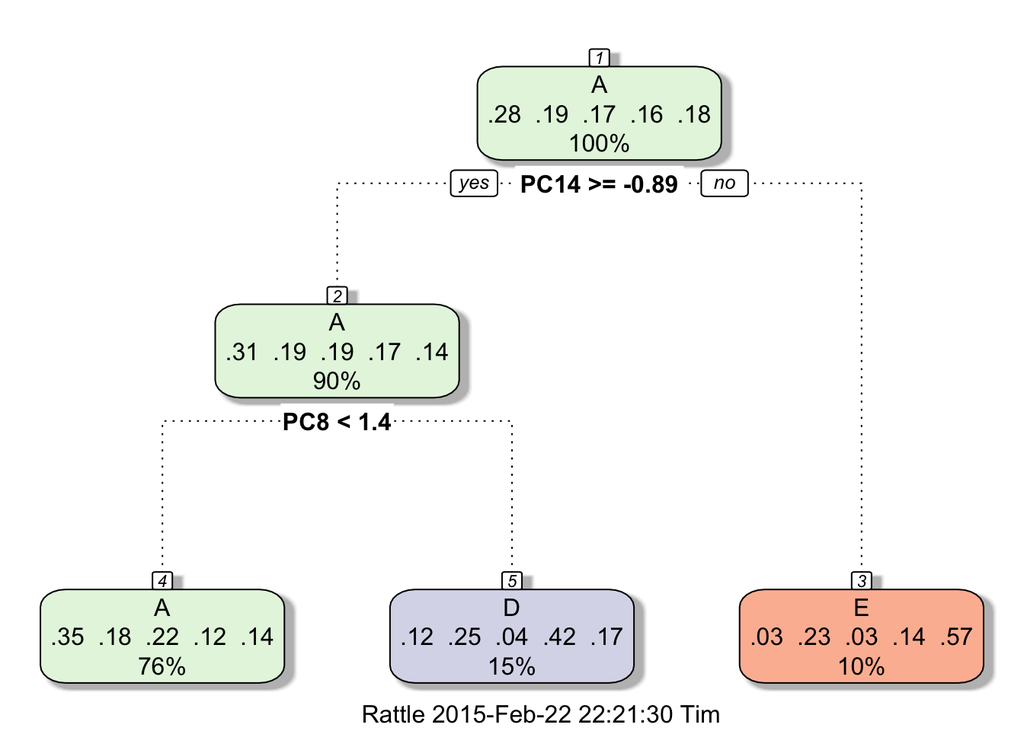

```r
fancyRpartPlot(modFit1$finalModel)
```

```r
confusionMatrix(predictions2, testing$classe)
```

```
## Confusion Matrix and Statistics
##
##           Reference
## Prediction    A    B    C    D    E
##          A 1267  393  411  353  142
##          B   20  314   29  134  128
##          C  101  242  415  317  233
##          D    0    0    0    0    0
##          E    7    0    0    0  398
##
## Overall Statistics
##
##                Accuracy : 0.4882
##                  95% CI : (0.4741, 0.5023)
##     No Information Rate : 0.2845
##     P-Value [Acc > NIR] : < 2.2e-16
##
##                   Kappa : 0.3308
##  Mcnemar's Test P-Value : NA
##
## Statistics by Class:
##
##                      Class: A Class: B Class: C Class: D Class: E
## Sensitivity            0.9082  0.33087  0.48538   0.0000  0.44173
## Specificity            0.6298  0.92137  0.77945   1.0000  0.99825
## Pos Pred Value         0.4938  0.50240  0.31728      NaN  0.98272
## Neg Pred Value         0.9453  0.85160  0.87764   0.8361  0.88820
## Prevalence             0.2845  0.19352  0.17435   0.1639  0.18373
## Detection Rate         0.2584  0.06403  0.08462   0.0000  0.08116
## Detection Prevalence   0.5232  0.12745  0.26672   0.0000  0.08259
## Balanced Accuracy      0.7690  0.62612  0.63242   0.5000  0.71999
```

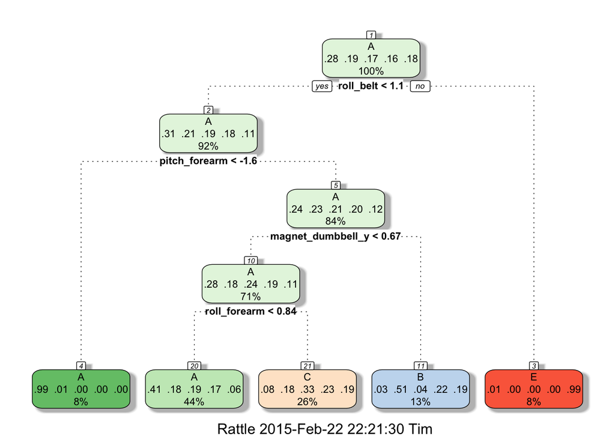

```r
fancyRpartPlot(modFit2$finalModel)
```

```r
confusionMatrix(predictions3, testing$classe)
```

```
## Confusion Matrix and Statistics
##
##           Reference
## Prediction    A    B    C    D    E
##          A 1267  393  411  353  142
##          B   20  314   29  134  128
##          C  101  242  415  317  233
##          D    0    0    0    0    0
##          E    7    0    0    0  398
##
## Overall Statistics
##
##                Accuracy : 0.4882
##                  95% CI : (0.4741, 0.5023)
##     No Information Rate : 0.2845
##     P-Value [Acc > NIR] : < 2.2e-16
##
##                   Kappa : 0.3308
##  Mcnemar's Test P-Value : NA
##
## Statistics by Class:
##
##                      Class: A Class: B Class: C Class: D Class: E
## Sensitivity            0.9082  0.33087  0.48538   0.0000  0.44173
## Specificity            0.6298  0.92137  0.77945   1.0000  0.99825
## Pos Pred Value         0.4938  0.50240  0.31728      NaN  0.98272
## Neg Pred Value         0.9453  0.85160  0.87764   0.8361  0.88820
## Prevalence             0.2845  0.19352  0.17435   0.1639  0.18373
## Detection Rate         0.2584  0.06403  0.08462   0.0000  0.08116
## Detection Prevalence   0.5232  0.12745  0.26672   0.0000  0.08259
## Balanced Accuracy      0.7690  0.62612  0.63242   0.5000  0.71999
```

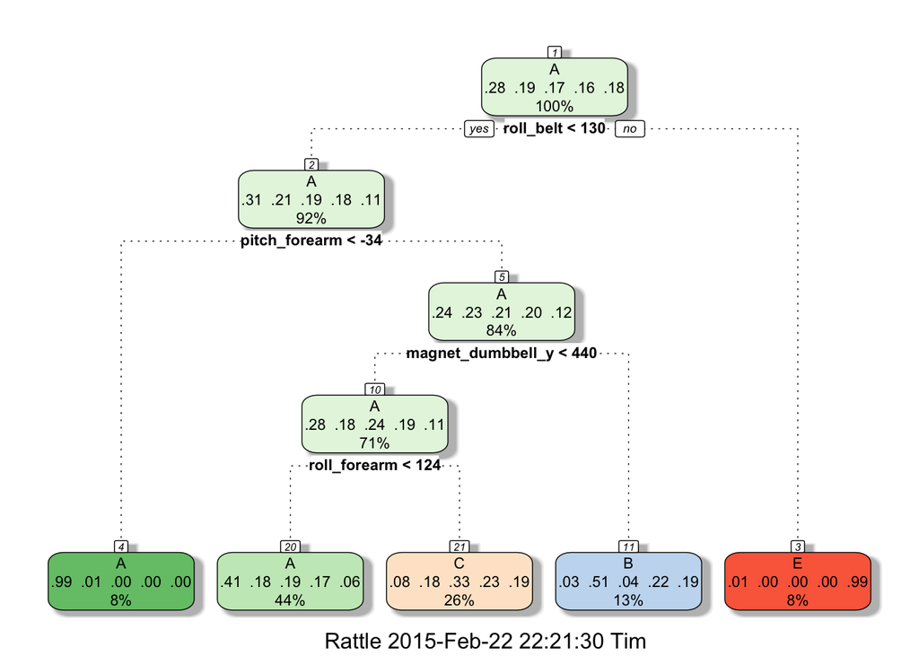

```r
fancyRpartPlot(modFit3$finalModel)
```

#### Random Forest

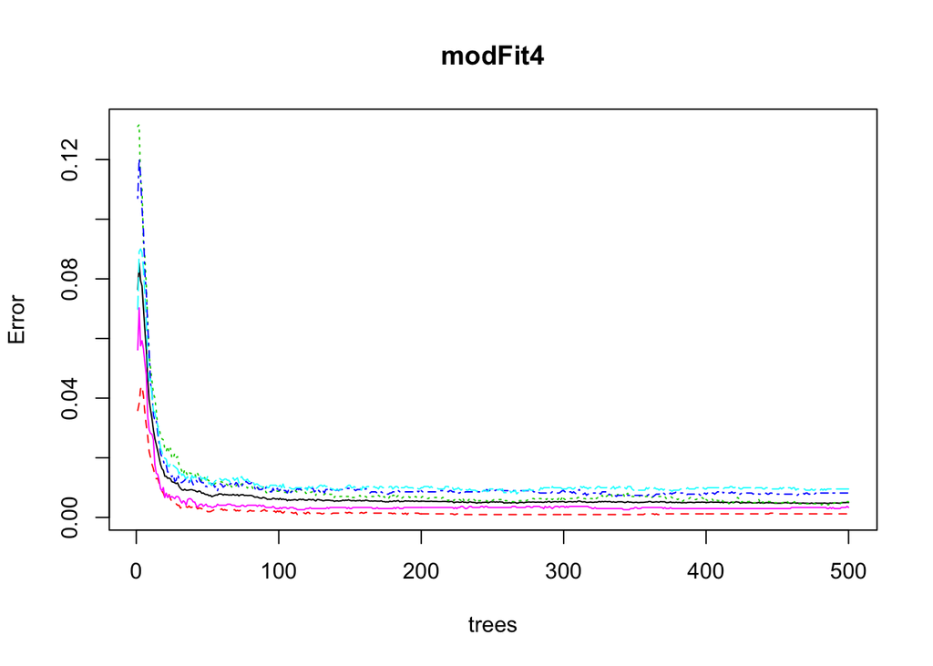

```r
plot(modFit4)
```

```r
modFit4
```

```
##
## Call:
##  randomForest(formula = classe ~ ., data = training, ntree = 500)
##                Type of random forest: classification
##                      Number of trees: 500
## No. of variables tried at each split: 7
##
##         OOB estimate of  error rate: 0.5%
## Confusion matrix:
##      A    B    C    D    E class.error
## A 4180    3    1    0    1 0.001194743
## B   11 2833    4    0    0 0.005266854
## C    0   16 2546    5    0 0.008180756
## D    0    0   21 2389    2 0.009535655
## E    0    0    1    8 2697 0.003325942
```

```r
confusionMatrix(predictions4, testing$classe)
```

```
## Confusion Matrix and Statistics
##
##           Reference
## Prediction    A    B    C    D    E
##          A 1394    0    0    0    0
##          B    1  949    0    0    0
##          C    0    0  855    2    1
##          D    0    0    0  802    0
##          E    0    0    0    0  900
##
## Overall Statistics
##
##                Accuracy : 0.9992
##                  95% CI : (0.9979, 0.9998)
##     No Information Rate : 0.2845
##     P-Value [Acc > NIR] : < 2.2e-16
##
##                   Kappa : 0.999
##  Mcnemar's Test P-Value : NA
##
## Statistics by Class:
##
##                      Class: A Class: B Class: C Class: D Class: E
## Sensitivity            0.9993   1.0000   1.0000   0.9975   0.9989
## Specificity            1.0000   0.9997   0.9993   1.0000   1.0000
## Pos Pred Value         1.0000   0.9989   0.9965   1.0000   1.0000
## Neg Pred Value         0.9997   1.0000   1.0000   0.9995   0.9998
## Prevalence             0.2845   0.1935   0.1743   0.1639   0.1837
## Detection Rate         0.2843   0.1935   0.1743   0.1635   0.1835
## Detection Prevalence   0.2843   0.1937   0.1750   0.1635   0.1835
## Balanced Accuracy      0.9996   0.9999   0.9996   0.9988   0.9994
```

#### The k-Nearest Neighbour Classification

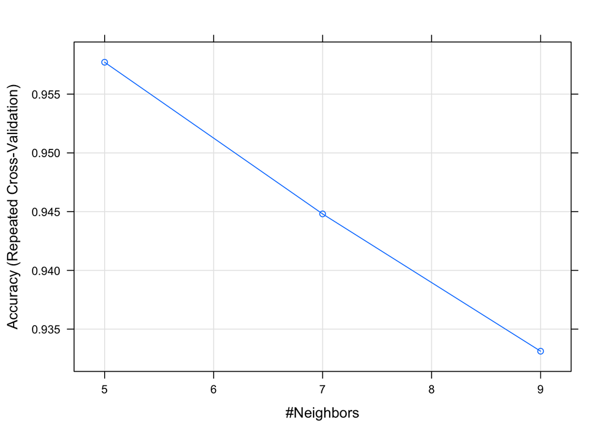

```r
plot(modFit5)
```

```r
confusionMatrix(predictions5, testing$classe)
```

```
## Confusion Matrix and Statistics
##
##           Reference
## Prediction    A    B    C    D    E
##          A 1383   16    2    3    0
##          B    4  916    6    2    3
##          C    5   15  838   21    3
##          D    2    1    9  776    6
##          E    1    1    0    2  889
##
## Overall Statistics
##
##                Accuracy : 0.9792
##                  95% CI : (0.9748, 0.983)
##     No Information Rate : 0.2845
##     P-Value [Acc > NIR] : < 2.2e-16
##
##                   Kappa : 0.9737
##  Mcnemar's Test P-Value : 0.005994
##
## Statistics by Class:
##
##                      Class: A Class: B Class: C Class: D Class: E
## Sensitivity            0.9914   0.9652   0.9801   0.9652   0.9867
## Specificity            0.9940   0.9962   0.9891   0.9956   0.9990
## Pos Pred Value         0.9850   0.9839   0.9501   0.9773   0.9955
## Neg Pred Value         0.9966   0.9917   0.9958   0.9932   0.9970
## Prevalence             0.2845   0.1935   0.1743   0.1639   0.1837
## Detection Rate         0.2820   0.1868   0.1709   0.1582   0.1813
## Detection Prevalence   0.2863   0.1898   0.1799   0.1619   0.1821
## Balanced Accuracy      0.9927   0.9807   0.9846   0.9804   0.9928
```

#### Final test

Eventually the random forest model was used for predicting the answers (activity classes) of the final test set (pml-testing.csv). Submission to Coursera confirmed it was the right choice as 100% of answers was correct.

```r
rpart1 <- predict(modFit1, newdata = pmltest1)
rpart2 <- predict(modFit2, newdata = pmltest1)
rpart3 <- predict(modFit3, newdata = pmltest1)
rf <- predict(modFit4, newdata = pmltest1)
knn <- predict(modFit5, newdata = pmltest1)
fp <- as.data.frame(NULL)
fp <- as.data.frame(rpart1)
fp$m2 <- as.data.frame(rpart2)
fp$m3 <- as.data.frame(rpart3)
fp$m4 <- as.data.frame(rf)
fp$m5 <- as.data.frame(knn)
fp
```

```
##    rpart1 rpart2 rpart3 rf knn
## 1       A      C      C  B   B
## 2       A      A      A  A   A
## 3       A      C      C  B   A
## 4       A      A      A  A   A
## 5       A      A      A  A   A
## 6       A      C      C  E   E
## 7       D      C      C  D   D
## 8       A      A      A  B   B
## 9       A      A      A  A   A
## 10      A      A      A  A   A
## 11      A      C      C  B   B
## 12      A      C      C  C   C
## 13      A      C      C  B   B
## 14      A      A      A  A   A
## 15      A      C      C  E   E
## 16      A      A      A  E   E
## 17      A      A      A  A   A
## 18      A      A      A  B   B
## 19      A      A      A  B   B
## 20      E      C      C  B   B
```